# Etude du cas biallèle

# Le cas du modèle biallélique (dit de Fisher)

## Introduction du modèle

Cette partie est essentiellement à visée pédagogique. Elle traite d’un cas à un locus et à deux allèles. Elle permet de comprendre le comportement des variances et des effets additifs dans un cas simple où on suppose connues les valeurs ‘biologiques’ des génotypes à un locus.

Dans la mesure où la cartographie, la génétique d’association et la prédiction de la valeur génomique sont basées sur une modélisation assez proche, le modèle biallélique peut permettre également de concevoir les effets d’une prédiction de la valeur génotypique à partir d’une décomposition mendélienne à des locus connus (marqueurs).

Exemples de populations bialléliques : - croisement de deux plantes homozygotes, - population créée à partir de l’autofécondation d’une plante tirée d’une population. - différentes populations dans lesquelles le polymoprhisme est biallélique comme le sont souvent les SNPs.

Dans les deux premiers cas, les deux allèles sont attendus en fréquence égale mais il peut exister d’autres populations pour lesquelles ce n’est pas le cas.

Considérons ici que la population est panmictique. A un locus, deux allèles B et b aux fréquences $p$ et $q$, avec $q=1-p$.

Trois génotypes sont possibles : BB : en fréquence $p^2$ Bb : en fréquence 2pq bb : en fréquence $q^2$.

Les valeurs biologiques moyennes des génotypes à ce locus sont arbitraires mais fixes dans le temps ($G_{bb}, G_{Bb} et G_{BB}$) , représentées en fig 1.

```r
# placer ici les valeurs à simuler
Gbb=1
GBb=1.7
GBB=2
```

La représentation graphique est la suivante.

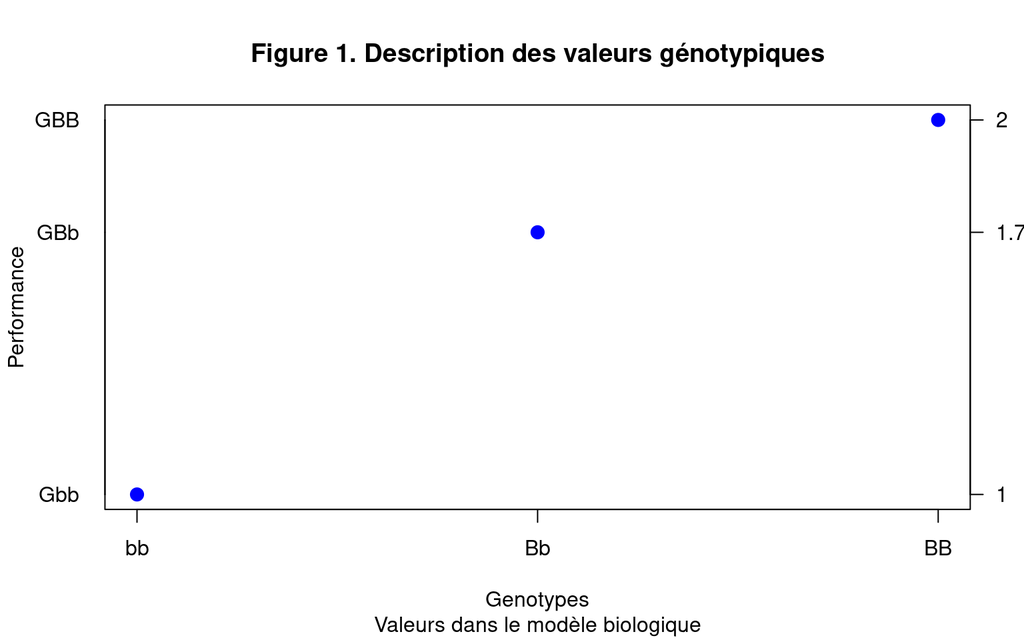

A partir de ces valeurs phénotypiques quelconques, nous allons faire un changement de repère.

Attention $c$ n’est pas la moyenne de la population ! C’est le milieu du segment entre les deux homozygotes.

Tout ceci revient à un changement de variables tel que
$$G_{bb} = c-a$$
$$G_{Bb} = c+d$$
$$G_{BB} = c+a$$

Cette ré-écriture simplifie ultérieurement les calculs et n’impose aucune contrainte.

```r
# Calcul des valeurs du modèle biallélique
c <- (GBB+Gbb) / 2
a <- GBB - c
d <- GBb - c
```

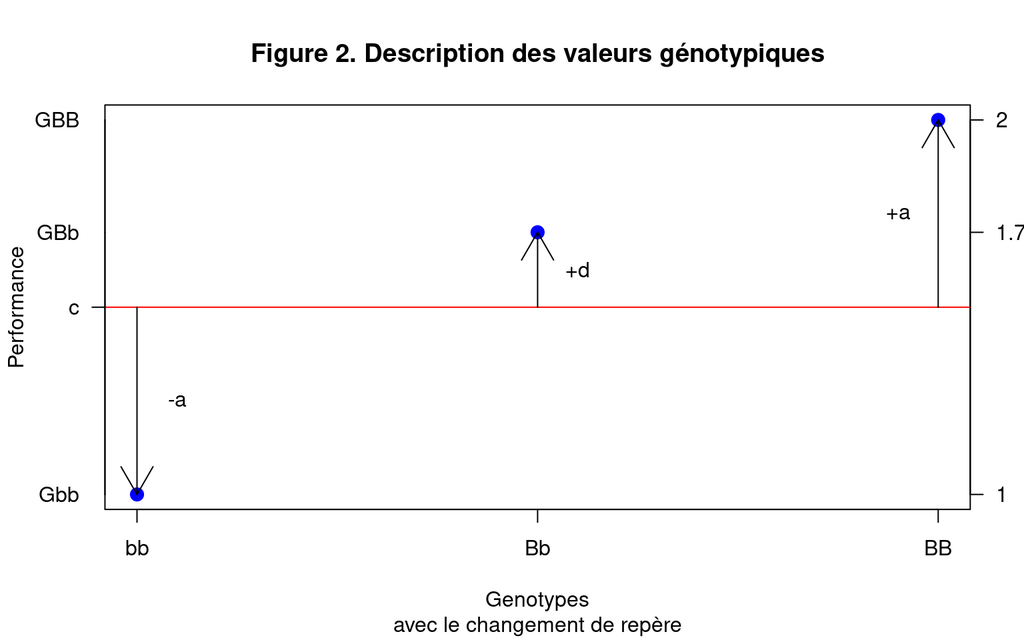

## Interpétation des paramètres

Le paramètre $d$ est un paramètre lié à dominance de l’allèle $B$ sur l’allèle $b$. Le degré de dominance peut être défini par $\frac{d}{a}$.

Si $\frac{d}{a} = 1$ , il y a dominance complète, le fait de posséder au moins une copie de l’allèle B donne la valeur maximale.  
Si $0< \frac{d}{a}<1$, il y a dominance partielle, soit favorable soit défavorable.  
et $\frac{d}{a}>1$, il y a superdominance, l’hétérozygote est meilleur que les deux homozygotes.

## Passage au modèle de décomposition des effets génétiques

Relions maintenant les génotypes moyens Y à la valeur génétique telle qu’elle s’écrit dans le modèle génétique:

$$G_{bb} = c-a = \mu + 2\alpha_{b} +
\beta_{bb}$$
$$G_{Bb} = c+d = \mu +
\alpha_{b} + \alpha_{B} + \beta_{bB}$$
$$G_{BB} = c+a = \mu + 2\alpha_{B} +
\beta_{BB}$$

### La moyenne

Si la population se reproduit en panmixie, la moyenne de la population $\mu$ vaut :

$$\mu= p^2 G_{BB} + 2pq G_{Bb} + q^2
G_{bb} = p^2 \left(c+a\right) + 2pq \left(c+d\right) +q^2
\left(c-a\right)$$

$$\mu= c +
a\left(p+q\right)\left(p-q\right) + 2 pqd = c + a\left(p-q\right) + 2
pqd$$

Regardons comment évolue la moyenne de la population en fonction de la fréquence de l’allèle $B$, $p$.

```r
mu<-NULL
# ici on indique un vecteur de fréquence pour lesquelles on veut calculer la moyenne
freq<-c(0:100)/100

# on ecrit une fonction qui donne la moyenne
mu <-function (c, a , d, p) {
                   mu<- c+ a*(p-1+p) + 2*p*(1-p)*d
                   return(mu) }

moyenne <- mu(c, a, d, freq)
```

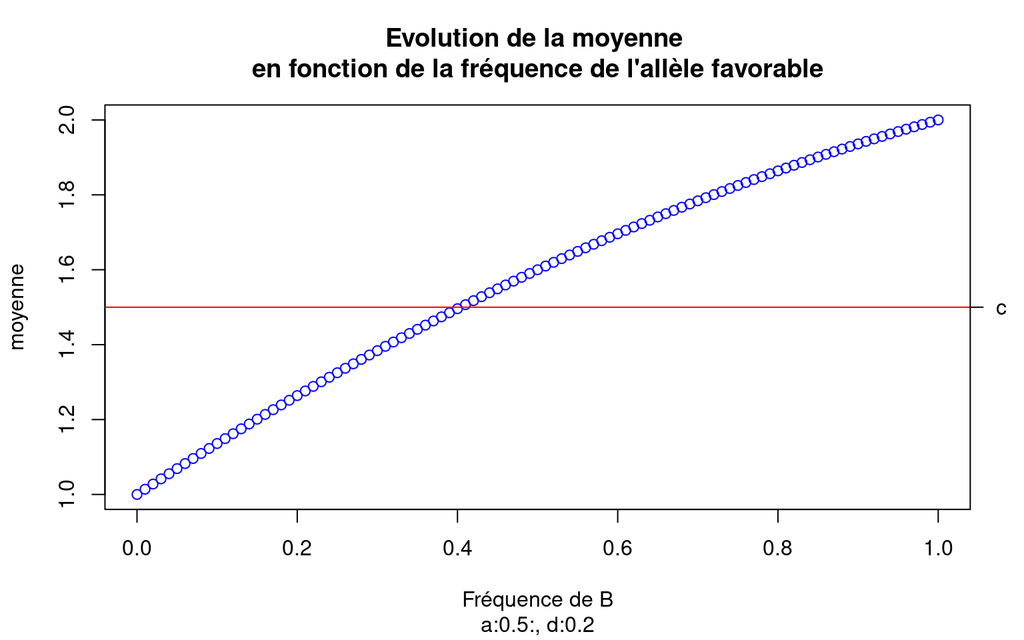

Vous pouvez constatez qu’en raison de l’existence d’un effet de dominance non nul, la courbe de la moyenne ne traverse pas la ligne horizontale d’ordonnée $c$ pour $p=1/2$.

### Les effets additifs

Nous avons défini de manière générale l’effet additif d’un allèle comme l’écart entre l’espérance génotypique des individus qui portent au moins une copie de cet allèle et la moyenne de la population.

$$\alpha_i=E_{j}\left(G_{ij}\right)-\mu=\sum_{j}p_{j}G_{ij}-\mu$$

Ainsi, dans le cas d’une population bi-allélique, l’effet additif de l’allèle $B$ se calcule de la manière suivante :

$\alpha_B=\left(pG_{BB}+ qG_{Bb} - \mu\right)$ puisque $p$ est la fréquence de $B$ et $q$ celle de $b$.

De même, $\alpha_b=pG_{Bb}+ qG_{bb} - \mu$

$$\alpha_B= p \left(c+a\right) + q
\left(c+d\right)- \left( c + \left(p-q\right)a +2pq d \right)$$
$$\alpha_B= a \left(q-p+p\right) +
\left(q-2p\right)d = q\left(a + \left(q-p\right)d\right)$$

Si on appelle $\alpha= a + \left(q-p\right)d$ alors $\alpha_B= q \alpha$ et par la même démarche on montre que $\alpha_b= -p \alpha$.

Nous remontrons ici que l’effet moyen d’un allèle est une fonction des fréquences alléliques : à effet biologique constant, le même allèle n’aura pas le même “effet moyen” dans le modèle génétique selon la population dans laquelle il se trouve.

### Les effets de dominance

Pour obtenir ces valeurs $\beta_{ij}$, il suffit de retrancher $\mu + \alpha_i + \alpha_j$ à la valeur de $G_{ij}$.

Par exemple, $\beta_{BB} = G_{ij}-2 \alpha_B-\mu$.

Et le calcul donne $\beta_{bb}= -2p^2 d$ $\beta_{Bb}= 2pq d$ $\beta_{bb}= -2q^2 d$

Vous pouvez remarquer que ces valeurs seront la plupart du temps assez faibles puisque elles sont affectées d’un produit $p^2$ ou $pq$.

### Interprétation en termes de régression géno-phénotypique

On peut en première approximation caractériser dans le système précédent un individu par sa dose d’allèles favorables $B$ : zéro (individu bb), un (individu Bb) ou deux (individu BB). Une première approximation de la relation entre phénotype et génotype est de ne considérer que les effets alléliques additifs : on prédirait alors un phénotype centré égal à $2\alpha_b$, $\alpha_b + \alpha_B$ ou $2\alpha_B$ respectivement pour ces trois cas : la relation entre la dose d’allèle B et la prédiction faite serait linéaire.

Etudions la relation par simulation de données (sans erreur d’échantillonnage)

```r
# Donner une  valeur de frequence pour p
p=0.2
q=1-p

# valeur de la moyenne
µ<-p**2*(c+a) + 2*p*q*(c+d) + q**2*(c-a)

# Valeur de alpha
alpha<-a+(q-p)*d

# les effets additifs des deux allèles
alpha_B<-   q * alpha
alpha_b <- -p * alpha

# les trois interactions
beta_bb = -2* d * p**2
beta_Bb =   2*p*q* d
beta_BB = -2*d* q**2

# Valeurs prédites avec le modèle additif dans le modèle bi allélique
PredBB <- µ + 2 * alpha_B
PredBb <- µ + alpha_B + alpha_b
Predbb <- µ + 2* alpha_b

# Nombre d'alleles B
x<-c(0,1,2)

# Valeurs biologiques associées
y<-c(c-a,c+d,c+a)

# valeurs predites
ypred<-c(Predbb,PredBb,PredBB)

# frequence de chacuns de genotypes en panmixie (bb, Bb et BB)
freq<-c(q**2,2*p*q,p**2)
```

Sur un graphe

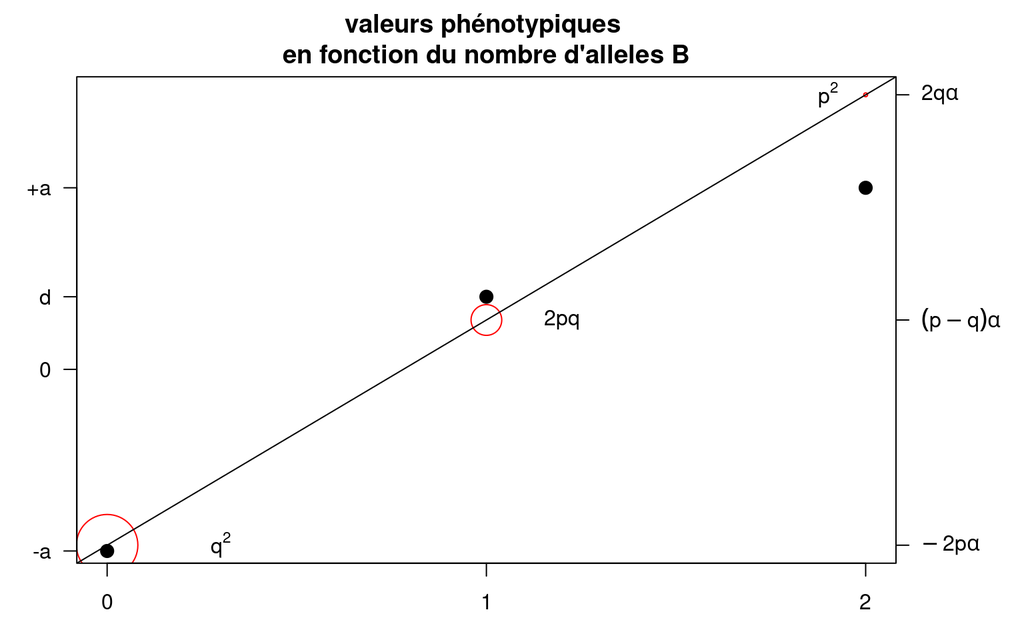

```r
# Graphe des  valeurs predites et la taille du point dépend des frequences
par(mar=c(3,3,3,5), oma=c(0,0,0,0))
plot(ypred~x, main="valeurs phénotypiques \nen fonction du nombre d'alleles B"
     , col="red", cex=10*freq, xlab="nombre d'alleles favorables",
     xaxt="n", yaxt="n")
axis(1, at=c(0,1,2), labels=c("0", "1", "2"))
text(0.3, Predbb, expression(q^2))
text(1.2, PredBb, expression(2*p*q))
text(1.9, PredBB, expression(p^2))

# les vraies valeurs
points(y~x, pch=20, cex=2)

axis(2, at=c(c-a,c,c+d,c+a), labels=c("-a","0","d","+a"), las=2)

# la pente de la régression
abline(a=Predbb,b=alpha)


# les breeding values
albb<-expression(-2*p*alpha)
albB<-expression((p-q)*alpha)
alBB<-expression(2*q*alpha)

axis(4, at=c(Predbb, PredBb, PredBB),
      labels=c(albb,albB,alBB), las=2)



title(sub="Figure 2. L'approche par la régression")
```

En noir,les valeurs génotypiques et en rouge les valeurs (additives) prédites par la régression sur le nombre de copie de l’allèle $B$.

Notez que la régression de pente $\alpha$ dépend des fréquences des trois génotypes et la droite de régression passe au voisinage des génotypes les plus fréquents. Ici Bb et bb dans notre exemple avec p=0.2 au détriment des génotypes les moins fréquents (ici les BB).

Utilisez ce script avec différentes valeurs de fréquences $p$, et de paramètres d’additivité et de dominance, $a$ et $d$ pour retracer ce type de figure et vous familiariser avec la notion de valeur additive.

La pente de la régression des valeurs additives sur le nombre d’allèles $B$ est $\alpha$ et on peut démontrer que $\alpha=\alpha_B-\alpha_b$.

Ainsi on appelle souvent $\alpha$ l’effet de subsitution de b par B. Cette démarche est utilisée couramment pour la détection de marqueurs en déséquilibre de liaison avec des locus à effets quantitatifs (QTLs).

### Evolution des variances

La variance additive
$$\sigma^2_A =
2E\left({\alpha_i}^2\right)
= 2 \left(\sum_{i=1}^n p_i\alpha_i^2\right)
= 2 \left(p_B\alpha_B^2 + p_b\alpha_b2\right)
= 2 \left(pq^2\alpha^2+ qp^2\alpha^2 \right)
= 2pq\alpha^2$$

De même pour la variance de dominance, on trouve
$$\sigma^2_D = 4p^2q^2d^2$$

L’évolution de $\sigma^2_A$ et de $\sigma^2_D$ est intéressante à suivre en fonction de $p$, $a$ et $d$.

Ci-dessous quelques exemples de changement des différentes composantes de la variance en fonction des fréquences alléliques

La variance additive est en bleu, la variance de dominance est en rouge.

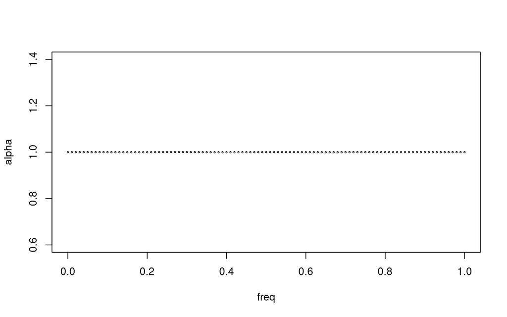

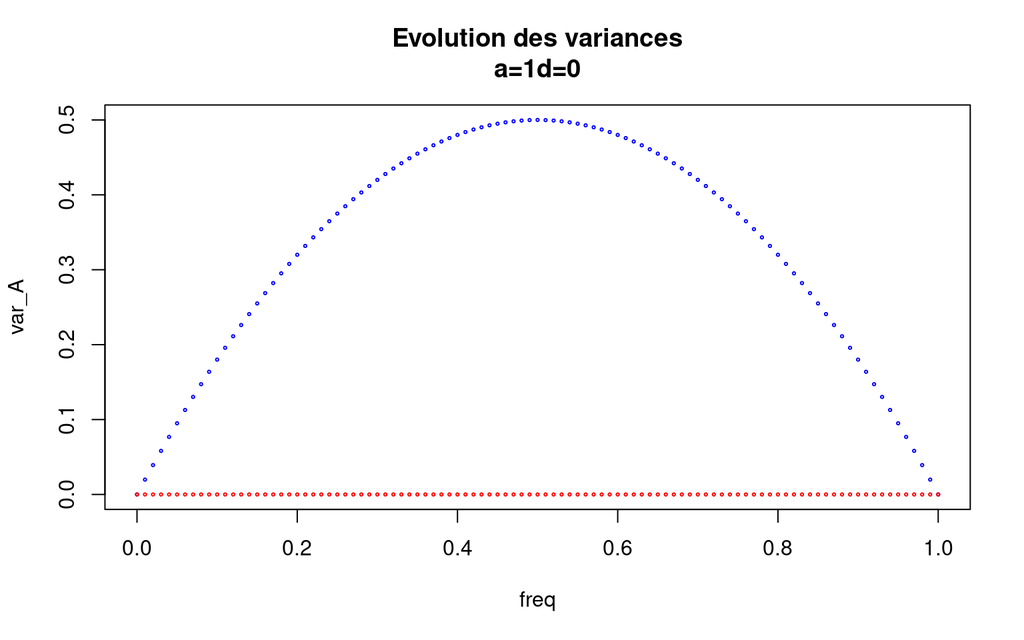

Avec de la dominance,

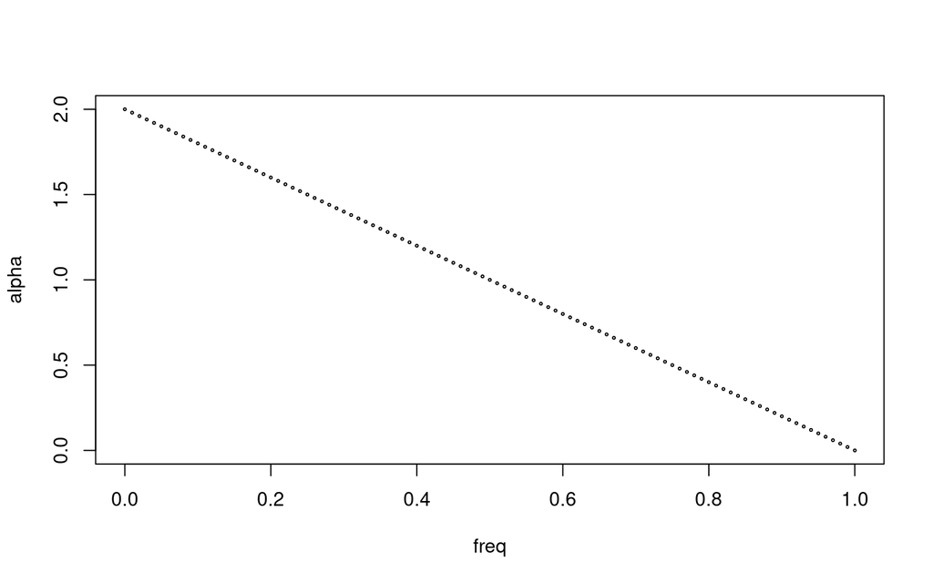

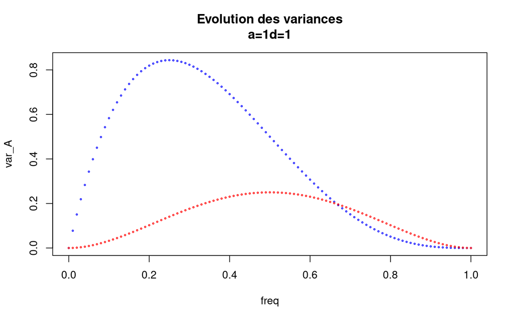

Avec de la super dominance,

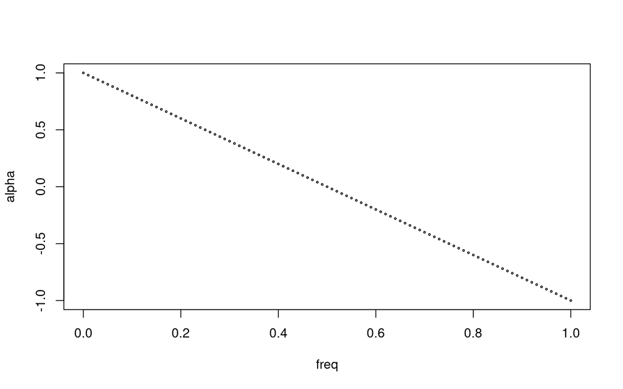

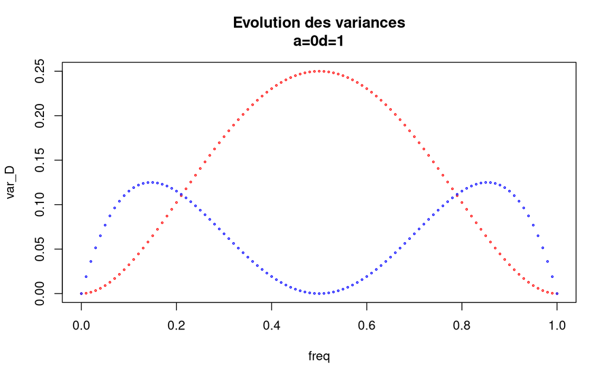

La variance dépend des fréquences. En fonction des paramètres de dominance et d’additivité, son maximum ne se situera pas au même endroit de l’espace des fréquences et la variance additive dépend pour partie des effets de dominance.

Ce phénomène est lié à l’apparition des hétérozygotes $Bb$ dans la population par rapport aux génotypes $BB$, pour les faibles valeurs de $p$, un allèle $B$ sera beaucoup plus souvent associé à un allèle $b$ qu’à un allèle $B$. Le calcul de la valeur additive de $B$ est donc d’autant plus grande qu’il y a un fort excès d’allèles $b$ par rapport à $B$.

Lorsque $p=q$, la valeur additive de $B$ ne dépend plus de la dominance biologique. Lorsque $B$ devient majoritaire, il créée moins de variance dans la population puisque l’hétérozygote a la même valeur que l’homozygote BB.

Attention donc au langage utilisé qui peut être source de confusion. La relation entre modèle biologique et statistique n’est pas simple.

### Cas des populations utilisées pour la détection de QTL

Cas des populations F2 (p=q=1/2)

On a alors $\alpha= a +(p-q) d = a$ et $\alpha_B=\frac{a}{2}$ et $\alpha_b=-\frac{a}{2}$. Entre les individus $BB$ et $bb$, il y a a bien une différence de $2a$.

La variance est de $\sigma_A^2=\frac{1}{2}a^2$ quelle que soit la valeur de d.

La valeur en sélection des allèles dépend de leur fréquence allélique. La probabilité qu’ils soient repérés dans un programme de génétique d’association dépend aussi de la variation phénotypiques qu’ils crééent dans la population (la valeur de a).

Dans un programme de sélection génomique, il sera plus facile d’utiliser dans un premier temps les locus qui ont la plus grande variance allélique puisque la différence de valeurs additive à l’intérieur de la population dans lesquels on les détecte est la plus grande.

### Application

Nous reprenons le simulateur de données que nous avons déjà vu dans le premier cours.

Exécuter ce script va produire une matrice de données génotypiques, une matrice de valeurs génotypiques, une de valeurs phénotypiques.

Nous pourrons donc explorer les régressions entre les génotypes et leurs valeurs en regardant le lien entre la performance et le nombre d’allèles favorables.

Créons d’abord notre population.

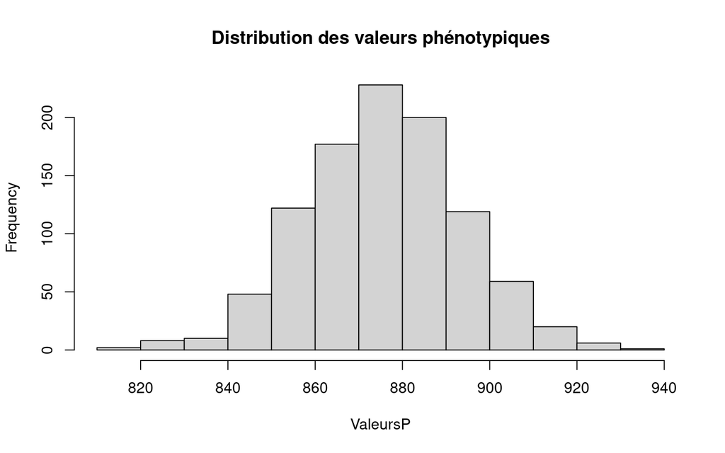

```r
# fonction qui donne la valeur de theta = 4Neµ
xi <- function(n,theta ){
i<-c(1:(2*n-1))
pi<-theta/i
return(pi)
}

# nombre d individus pour la découverte des fréquences alléliques (Ewens)
n<-50

# proportions des frequences alleliques
freq<-xi(n,0.10)

# tirage des frequences alleliques
L<-100
Locus<-NULL
for(i in 1:L) {
        tirage<-rmultinom(1, size = 1, prob = freq)
        classe <- which(tirage>0)
        Locus[i]<-classe/2/n
        }

## Construction de la matrice des genotypes
# nombre d'individus
n_ind<-1000
genotype <-matrix(nrow=n_ind, ,ncol=L)

for(i in 1:L) {
        pA<-Locus[i]
        pa<-1-pA
        tirage<-rmultinom(n_ind, size = 1, prob = c(2*pA*pa, pA*pA,  pa*pa))
        genotype[,i]<-((which(tirage>0))%%3-1)*2
}

# ici a vaut 2
ValeursG<-apply(genotype, 1, sum)
ValeursE<-rnorm(n_ind, mean=0, sd=15)

# valeur de la moyenne, tous les autres effets etant centrés
centrage<-1000
ValeursG<-centrage + ValeursG
ValeursP<-ValeursG + ValeursE

hist(ValeursP, main="Distribution des valeurs phénotypiques")
```

```r
## Valeurs génétiques
### Que se passe t il à un locus ?

Nb_Alleles_favorables<-genotype
Nb_Alleles_favorables[Nb_Alleles_favorables==2]<-2
Nb_Alleles_favorables[Nb_Alleles_favorables==0]<-1
Nb_Alleles_favorables[Nb_Alleles_favorables==-2]<-0

# il faut transformer les données en numériques pour la régression
Nb_Alleles_favorables<-apply(Nb_Alleles_favorables,2,function(x) { x<-as.numeric(x)})
```

Nous pouvons vérifier que la simulation a bien fonctionné. Regardons le lien entre les fréquences théoriques et celles qui ont été réalisées dans la simulation.

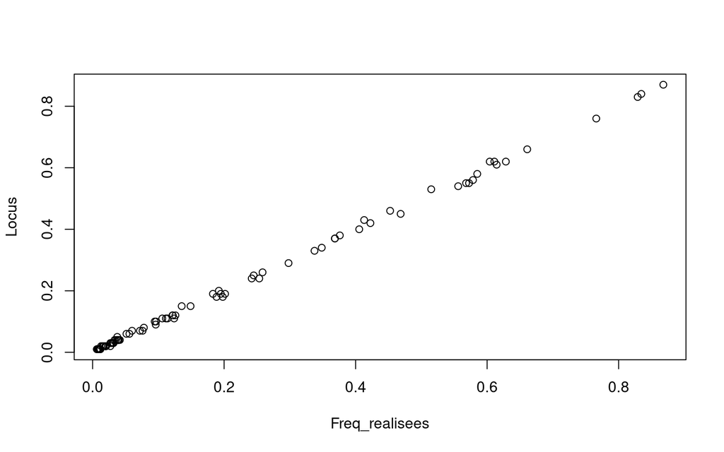

```r
# Les fréquences réalisées
Freq_realisees<-apply(Nb_Alleles_favorables,2,sum)/n_ind/2

# elles sont proches des valeurs simulées
plot(Freq_realisees,Locus)
```

Pour étudier la relation entre les génotypes et les valeurs génotypiques, nous pouvons regarder ce qui se passe à un locus.

```r
# choisissez le locus
i<-4

# les effectifs génotypiques
table(Nb_Alleles_favorables[,i])
```

```
##
##   0   1
## 961  39
```

```r
# quelle est la fréquence de A à ce locus
Freq_realisees[i]
```

```
## [1] 0.0195
```

```r
# Representation graphique
boxplot(ValeursG ~Nb_Alleles_favorables[,i])

# les moyennes par génotypes
moyenne_Geno<-aggregate(ValeursG, list(Geno=Nb_Alleles_favorables[,i]), mean)
moyenne_Geno
```

```
##   Geno        x
## 1    0 875.7565
## 2    1 877.3333
```

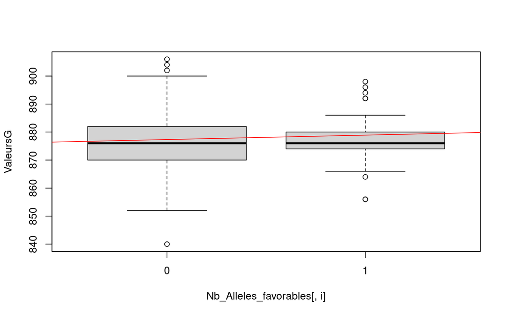

```r
# les paramètres de la regression, une fonction
regression_f<-function(Valeurs,Nb_Alleles) {
             modele<-lm(Valeurs~Nb_Alleles)
             intercept<-modele$coefficients[1]
             beta<-modele$coefficients[2]
            return(list(intercept, beta))
            }

R<-regression_f(ValeursG,Nb_Alleles_favorables[,i])

intercept<-R[[1]]
beta<-R[[2]]

abline(a=intercept, b=beta, col="red")
```

```r
# la pente attendue alpha = a +(p-q)d
alpha<-2+(2*Freq_realisees[i]-1)*0
alpha
```

```
## [1] 2
```

```r
# a comparer avec beta
beta
```

```
## Nb_Alleles
##    1.57683
```

Les breeding values

L’effet additif de $B$ est donc $\alpha_B=q\alpha$ et la breeding value de $G_{BB}$ vaut $µ+2\alpha_B$.

Les individus $BB$ ont donc comme breeding value (centrées)

```r
Breeding_BB=2*(1-Freq_realisees[i])*beta
Breeding_BB
```

```
## Nb_Alleles
##   3.092163
```

```r
Breeding_Bb=(1-Freq_realisees[i]-Freq_realisees[i])*beta
Breeding_Bb
```

```
## Nb_Alleles
##   1.515333
```

```r
Breeding_bb=-2*(Freq_realisees[i])*beta
Breeding_bb
```

```
##  Nb_Alleles
## -0.06149636
```

```r
VA<-2*Freq_realisees[i]*(1-Freq_realisees[i])*beta
VA
```

```
## Nb_Alleles
## 0.06029718
```

Explorez plusieurs locus qui ont des fréquences très différentes entre [0,1] et regardez comment évoluent les breedings values et les variances.

Au lieu d’utiliser la régression sur les valeurs génotypiques, faites là sur la valeur phénotypique.

Il suffit de remplacer ValeursG par valeursP…

```r
# Representation graphique
boxplot(ValeursP ~Nb_Alleles_favorables[,i])

# les moyennes par génotypes
moyenne_Geno<-aggregate(ValeursP, list(Geno=Nb_Alleles_favorables[,i]), mean)
moyenne_Geno
```

```
##   Geno        x
## 1    0 875.5730
## 2    1 877.3656
```

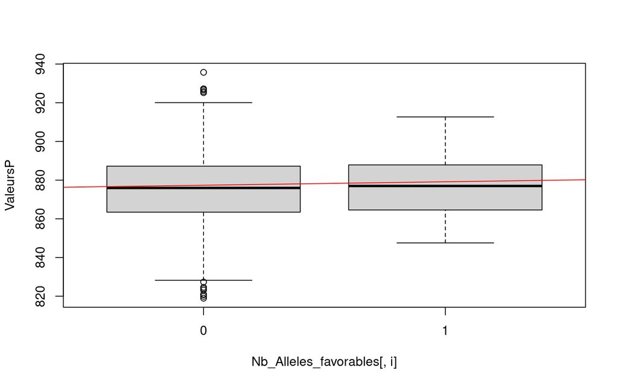

```r
R<-regression_f(ValeursP,Nb_Alleles_favorables[,i])

intercept<-R[[1]]
beta<-R[[2]]

abline(a=intercept, b=beta, col="red")
```

```r
# la pente attendue alpha = a +(p-q)d
alpha<-2+(2*Freq_realisees[i]-1)*0
alpha
```

```
## [1] 2
```

```r
# a comparer avec beta
beta
```

```
## Nb_Alleles
##   1.792568
```

Discutez…